# Using SparkR with 2013 NYCTaxi Data: Data wrangling, manipulations, modeling, and evaluation

Algorithms and Data Science & R Server Teams, Microsoft Data Group

March 10, 2017

# 1 Introduction

This Markdown document shows the use of [SparkR](https://spark.apache.org/docs/latest/sparkr.html) for data wrangling, manipulation, and creating machine learning models. The data used for this exercise is the public NYC Taxi Trip and Fare data-set (2013, December, ~4 Gb, ~13 million rows) available from: http://www.andresmh.com/nyctaxitrips. Data for this exercise can be downloaded from the public blob (see below). The data can be uploaded to the blob (or other storage) attached to your HDInsight cluster (HDFS) and used as input into the scripts shown here.

We use Spark SQL for many of the data wrangling tasks. For plotting and visualization, small amounts of data from Spark dataframes are transformed to the local data frames.

# 2 Creating spark connection, loading packages

```r
###########################################
# LOAD LIBRARIES FROM SPECIFIED PATH
###########################################
Sys.setenv(YARN_CONF_DIR="/opt/hadoop/current/etc/hadoop",
           HADOOP_HOME="/opt/hadoop/current",
           JAVA_HOME = "/usr/lib/jvm/java-1.8.0-openjdk-1.8.0.111-1.b15.el7_2.x86_64",
           SPARK_HOME = "/dsvm/tools/spark/current",
           PATH=paste0(Sys.getenv("PATH"),":/opt/hadoop/current/bin:/dsvm/tools/spark/current/bin"))
### *** NOTE: Spark paths are different in DSVM and HDI cluster *** ###

.libPaths(c(file.path(Sys.getenv("SPARK_HOME"), "R", "lib"), .libPaths()))
library(SparkR)
library(rmarkdown)
library(knitr)
library(gridExtra)
library(ggplot2)

###########################################
# CREATE SPARK CONTEXT
###########################################
sc <- sparkR.session(
  sparkPackages = "com.databricks:spark-csv_2.10:1.3.0"
)
```

```
## Launching java with spark-submit command /dsvm/tools/spark/current/bin/spark-submit  --packages com.databricks:spark-csv_2.10:1.3.0 sparkr-shell /tmp/Rtmp6Osd0y/backend_port6b965773f8b7
```

```r
SparkR::setLogLevel("OFF")
```

```r
### *** NOTE: spark.master can be set to use "yarn" on HDInsight clusters *** ###

###########################################
## SPECIFY BASE HDFS DIRECTORY
###########################################
fullDataDir <- "/user/RevoShare/remoteuser/Data"
system("hadoop fs -ls /user/RevoShare/remoteuser/Data")
### *** NOTE: HDFS file paths are different in DSVM and HDInsight cluster *** ###
```

# 3 Reading files from HDFS (csv or parquet format)

Data for this exercise can be downloaded from the public blob locations below:  
1. Trip (Csv): http://cdspsparksamples.blob.core.windows.net/data/NYCTaxi/KDD2016/trip_data_12.csv  
2. Fare (Csv): http://cdspsparksamples.blob.core.windows.net/data/NYCTaxi/KDD2016/trip_fare_12.csv  
The data can be uploaded to the blob (or other storage) attached to your HDInsight cluster (HDFS) and used as input into the scripts shown here. The csv files can be read into Spark context and saved in parquet format. Once saved in parquet format, data can be read in much more quickly than csv files.

```r
starttime <- Sys.time();
###########################################
# LIST FILES FROM HDFS
###########################################
system("hadoop fs -ls /user/RevoShare/remoteuser/Data")

###########################################
# TRIP FILE (parquet format, CSV only shown for reference)
###########################################
#tripPathCSV <- file.path(fullDataDir, "trip_data_12.csv")
#tripDF <- read.df(tripPathCSV, source = "com.databricks.spark.csv", header = "true", inferSchema = "true")
#SparkR::cache(tripDF); SparkR::count(tripDF)
#write.df(tripDF, file.path(fullDataDir, "TripData2013DecParquet"), "parquet", "overwrite")
tripPath <- file.path(fullDataDir, "TripData2013DecParquet")
tripDF <- read.df (tripPath, source = "parquet")
printSchema(tripDF)
```

```
## root
##  |-- medallion: string (nullable = true)
##  |-- hack_license: string (nullable = true)
##  |-- vendor_id: string (nullable = true)
##  |-- rate_code: integer (nullable = true)
##  |-- store_and_fwd_flag: string (nullable = true)
##  |-- pickup_datetime: timestamp (nullable = true)
##  |-- dropoff_datetime: timestamp (nullable = true)
##  |-- passenger_count: integer (nullable = true)
##  |-- trip_time_in_secs: integer (nullable = true)
##  |-- trip_distance: double (nullable = true)
##  |-- pickup_longitude: double (nullable = true)
##  |-- pickup_latitude: double (nullable = true)
##  |-- dropoff_longitude: double (nullable = true)
##  |-- dropoff_latitude: double (nullable = true)
```

```r
SparkR::cache(tripDF); SparkR::count(tripDF)
```

```
## SparkDataFrame[medallion:string, hack_license:string, vendor_id:string, rate_code:int, store_and_fwd_flag:string, pickup_datetime:timestamp, dropoff_datetime:timestamp, passenger_count:int, trip_time_in_secs:int, trip_distance:double, pickup_longitude:double, pickup_latitude:double, dropoff_longi…
```

```
## [1] 13971118
```

```r
head(tripDF, 3)
```

```
##                          medallion                     hack_license
## 1 274157A7E6A1820B13BB747B086462AD AB02E290BE9B06110B56E58EC34AEBEB
## 2 08257250116FC8B672F7B148D8D023B9 F98F7866BAEE6E0E2F1ADA23AA1578FE
## 3 135A8EDC6EBD6F4397B7A6D281C75AB0 2A560563544C372864592E0DA3FB34AE
##   vendor_id rate_code store_and_fwd_flag     pickup_datetime
## 1       VTS         1                 NA 2013-12-01 13:02:00
## 2       VTS         1                 NA 2013-12-01 13:20:00
## 3       VTS         1                 NA 2013-12-01 13:23:00
##      dropoff_datetime passenger_count trip_time_in_secs trip_distance
## 1 2013-12-01 13:20:00               1              1080          3.77
## 2 2013-12-01 13:29:00               1               540          1.79
## 3 2013-12-01 13:31:00               5               480          0.75
##   pickup_longitude pickup_latitude dropoff_longitude dropoff_latitude
## 1        -74.00285        40.76052         -74.01007         40.71142
## 2        -74.00649        40.73297         -74.01484         40.71127
## 3        -73.96761        40.76290         -73.97512         40.76524
```

```r
###########################################
# FARE FILE (parquet format)
###########################################
farePath <- file.path(fullDataDir, "FareData2013DecParquet")
fareDF <- read.df (farePath, source = "parquet")
printSchema(fareDF)
```

```
## root
##  |-- medallion: string (nullable = true)
##  |-- hack_license: string (nullable = true)
##  |-- vendor_id: string (nullable = true)
##  |-- pickup_datetime: timestamp (nullable = true)
##  |-- payment_type: string (nullable = true)
##  |-- fare_amount: double (nullable = true)
##  |-- surcharge: double (nullable = true)
##  |-- mta_tax: double (nullable = true)
##  |-- tip_amount: double (nullable = true)
##  |-- tolls_amount: double (nullable = true)
##  |-- total_amount: double (nullable = true)
```

```r
SparkR::cache(fareDF); SparkR::count(fareDF)
```

```
## SparkDataFrame[medallion:string, hack_license:string, vendor_id:string, pickup_datetime:timestamp, payment_type:string, fare_amount:double, surcharge:double, mta_tax:double, tip_amount:double, tolls_amount:double, total_amount:double]
```

```
## [1] 13971118
```

```r
head(fareDF, 3)
```

```
##                          medallion                     hack_license
## 1 343EE0E83B908DC51AA01245FDC32974 29BABE0FFB16752B5A1DC5E4AD91EA4A
## 2 1803A06155B880D1027E09C12042C949 5D03700E691CEC54E6EA1E13E846DBAA
## 3 E79F0C20DD4108BCD139A88F90220099 412977BC1257772EE2A0FE5F52628BEB
##   vendor_id     pickup_datetime payment_type fare_amount surcharge mta_tax
## 1       CMT 2013-12-17 22:00:32          CSH         6.0       0.5     0.5
## 2       CMT 2013-12-17 22:07:01          CSH         7.0       0.5     0.5
## 3       CMT 2013-12-17 22:08:20          CSH         4.5       0.5     0.5
##   tip_amount tolls_amount total_amount
## 1          0            0          7.0
## 2          0            0          8.0
## 3          0            0          5.5
```

```r
endtime <- Sys.time();
print (endtime - starttime);
```

```
## Time difference of 44.65277 secs
```

# 4 Data wrangling & cleanup using SQL

SparkR is an R package that provides a light-weight frontend to use Apache Spark from R. In Spark 2.0, SparkR provides a distributed data frame implementation that supports operations like selection, filtering, aggregation etc. (similar to R data frames, dplyr) but on large datasets. SparkR also provides support for distributed machine learning using MLlib.

You can register dataframes as tables in SQLContext and join using multiple columns. The following SQL also filters the data for some outliers.

```r
###########################################
# 1. REGISTER TABLES AND JOIN ON MULTIPLE COLUMNS, FILTER DATA
# 2. REGISTER JIONED TABLE
###########################################
starttime <- Sys.time();

createOrReplaceTempView(tripDF, "trip")
createOrReplaceTempView(fareDF, "fare")

trip_fareDF <-  SparkR::sql("SELECT
  f.pickup_datetime, hour(f.pickup_datetime) as pickup_hour,
  t.dropoff_datetime, hour(t.dropoff_datetime) as dropoff_hour,
  f.vendor_id, f.fare_amount, f.surcharge, f.tolls_amount,
  f.tip_amount, f.payment_type, t.rate_code,
  t.passenger_count, t.trip_distance, t.trip_time_in_secs,
  t.pickup_longitude, t.pickup_latitude, t.dropoff_longitude,
  t.dropoff_latitude
  FROM trip t, fare f
  WHERE t.medallion = f.medallion AND t.hack_license = f.hack_license
  AND t.pickup_datetime = f.pickup_datetime
  AND t.passenger_count > 0 and t.passenger_count < 8
  AND f.tip_amount >= 0 AND f.tip_amount <= 15
  AND f.fare_amount >= 1 AND f.fare_amount <= 150
  AND f.tip_amount < f.fare_amount AND t.trip_distance > 0
  AND t.trip_distance <= 40 AND t.trip_distance >= 1
  AND t.trip_time_in_secs >= 30 AND t.trip_time_in_secs <= 7200
  AND t.rate_code <= 5 AND f.payment_type in ('CSH','CRD')")
createOrReplaceTempView(trip_fareDF, "trip_fare")

###########################################
# Cache joined DF in memory
###########################################
SparkR::cache(trip_fareDF); SparkR::count(trip_fareDF);
```

```
## SparkDataFrame[pickup_datetime:timestamp, pickup_hour:int, dropoff_datetime:timestamp, dropoff_hour:int, vendor_id:string, fare_amount:double, surcharge:double, tolls_amount:double, tip_amount:double, payment_type:string, rate_code:int, passenger_count:int, trip_distance:double, trip_time_in_secs…
```

```
## [1] 10710669
```

```r
###########################################
# SHOW REGISTERED TABLES
###########################################
head(SparkR::sql("show tables"))
```

```
##   tableName isTemporary
## 1      fare        TRUE
## 2      trip        TRUE
## 3 trip_fare        TRUE
```

```r
endtime <- Sys.time();
print (endtime - starttime);
```

```
## Time difference of 1.090564 mins
```

# 5 Feature engineering using SQL

You can create new features using sQL statements. For example, you can use case statements to generate categorical features from coneunuous (numerical) ones.

```r
###########################################
# CREATE FEATURES IN SQL USING CASE STATEMENTS
###########################################
starttime <- Sys.time();

trip_fare_feat <- SparkR::sql("SELECT
    payment_type, pickup_hour, fare_amount, tip_amount,
    passenger_count, trip_distance, trip_time_in_secs,
  CASE
    WHEN (pickup_hour <= 6 OR pickup_hour >= 20) THEN 'Night'
    WHEN (pickup_hour >= 7 AND pickup_hour <= 10) THEN 'AMRush'
    WHEN (pickup_hour >= 11 AND pickup_hour <= 15) THEN 'Afternoon'
    WHEN (pickup_hour >= 16 AND pickup_hour <= 19) THEN 'PMRush'
    END as TrafficTimeBins,
  CASE
    WHEN (tip_amount > 0) THEN 1
    WHEN (tip_amount <= 0) THEN 0
    END as tipped
  FROM trip_fare")

SparkR::cache(trip_fare_feat); SparkR::count(trip_fare_feat);
```

```
## SparkDataFrame[payment_type:string, pickup_hour:int, fare_amount:double, tip_amount:double, passenger_count:int, trip_distance:double, trip_time_in_secs:int, TrafficTimeBins:string, tipped:int]
```

```
## [1] 10710669
```

```r
createOrReplaceTempView(trip_fare_feat, "trip_fare_feat")
head(trip_fare_feat, 3)
```

```
##   payment_type pickup_hour fare_amount tip_amount passenger_count
## 1          CRD          15         8.0        1.7               1
## 2          CRD           1        12.0        2.6               2
## 3          CRD          23        11.5        1.0               2
##   trip_distance trip_time_in_secs TrafficTimeBins tipped
## 1           1.6               532       Afternoon      1
## 2           3.1               653           Night      1
## 3           2.6               812           Night      1
```

```r
endtime <- Sys.time();
print (endtime - starttime);
```

```
## Time difference of 6.499619 secs
```

# 6 Data visualization

## 6.1 Plots to inspect data and relationships between variables

For visualization, a small portion data will have to be sampled and brought into local memory as a data.frame object. R’s plotting functions (e.g. from those in ggplot package) can then be applied to the data.frame for visualization.

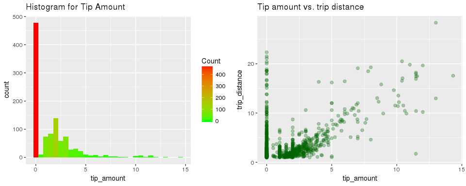

```r
###########################################
# SAMPLE SMALL PORTION OF DATA FOR VISUALIZATION
###########################################
starttime <- Sys.time();

trip_fare_featSampled <- SparkR::sample(trip_fare_feat, withReplacement=FALSE,
                                fraction=0.0001, seed=123)

###########################################
# CONVERT SPARK DF TO LOCAL DATA.FRAME IN MEMORY OF R-SERVER EDGE NODE
###########################################
trip_fare_featSampledDF <- as.data.frame(trip_fare_featSampled);

###########################################
# Generate HISTOGRAM OF TIP AMOUNT
###########################################
hist <- ggplot(trip_fare_featSampledDF, aes(x=tip_amount)) +
  geom_histogram(binwidth = 0.5, aes(fill = ..count..)) +
  scale_fill_gradient("Count", low = "green", high = "red") +
  labs(title="Histogram for Tip Amount");

###########################################
# Generate Scatter Plot OF TRIP DISTANCE vs. TIP AMOUNT
###########################################
scatter <- ggplot(trip_fare_featSampledDF, aes(tip_amount, trip_distance)) +
  geom_point(col='darkgreen', alpha=0.3, pch=19, cex=2) +
  labs(title="Tip amount vs. trip distance");

###########################################
# Plot Histogram and Scatter Plot OF TIP AMOUNT Side by Side
###########################################
grid.arrange(hist, scatter, ncol=2)
```

```r
endtime <- Sys.time();
print (endtime - starttime);
```

```
## Time difference of 1.678182 secs
```

## 6.2 Advanced summarization using SQL and plotting:

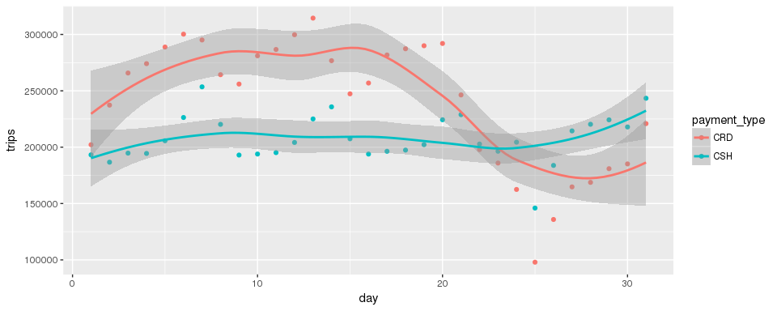

```r
###########################################
# GROUP TRIPS BY YEAR, MONTH, DAY, PAYMENT TYPE
###########################################
starttime <- Sys.time();

trip_stats_by_day <- SparkR::sql("select
      year(pickup_datetime) as year, month(pickup_datetime) as month,
      day(pickup_datetime) as day, payment_type, count(1) as trips
      from fare
      where payment_type in ('CSH','CRD')
      group by year(pickup_datetime), month(pickup_datetime),
      day(pickup_datetime), payment_type")
tsbd <- as.data.frame(trip_stats_by_day)

###########################################
# PLOT NUMBER OF TRIPS BY DAY IN DEC 2013
###########################################
ggplot(data=tsbd, aes(day, trips)) +
  geom_point(aes(color=payment_type)) +
  geom_smooth(aes(color=payment_type))
```

```r
endtime <- Sys.time();
print (endtime - starttime);
```

```
## Time difference of 5.599727 secs
```

# 7 Modeling with SparkR

## 7.1 Down-sample data for modeling

```r
###########################################
# SAMPLE DATA FOR MODELING
###########################################
starttime <- Sys.time();

trip_fare_featSampled <- SparkR::sample(trip_fare_feat, withReplacement=FALSE,
                                fraction=0.1, seed=123)
SparkR::cache(trip_fare_featSampled); SparkR::count(trip_fare_featSampled);
```

```
## SparkDataFrame[payment_type:string, pickup_hour:int, fare_amount:double, tip_amount:double, passenger_count:int, trip_distance:double, trip_time_in_secs:int, TrafficTimeBins:string, tipped:int]
```

```
## [1] 1071935
```

```r
createOrReplaceTempView(trip_fare_featSampled, "trip_fare_featSampled")

endtime <- Sys.time();
print (endtime - starttime);
```

```
## Time difference of 1.761098 secs
```

## 7.2 Partition data into train/test

```r
###########################################
# PARTITION DATA INTO TRAIN-TEST USIN SQL
###########################################
dfrand <- SparkR::sql("SELECT *, RAND() as randnum from trip_fare_featSampled" );
trainDF <- SparkR::filter(dfrand, dfrand$randnum <= 0.7)
testDF <- SparkR::filter(dfrand, dfrand$randnum > 0.7)
head(trainDF, 3)
```

```
##   payment_type pickup_hour fare_amount tip_amount passenger_count
## 1          CRD           5        10.5        1.0               1
## 2          CSH          13         7.5        0.0               1
## 3          CRD          18         7.5        1.7               1
##   trip_distance trip_time_in_secs TrafficTimeBins tipped   randnum
## 1          2.80               451           Night      1 0.2592047
## 2          1.00               571       Afternoon      0 0.2328304
## 3          1.36               540          PMRush      1 0.2528229
```

```r
endtime <- Sys.time();
print (endtime - starttime);
```

```
## Time difference of 1.958512 secs
```

## 7.3 Create a SparkR::glm model

```r
###########################################
## CREATE GLM MODEL
###########################################
starttime <- Sys.time();

model <- SparkR::spark.glm(tip_amount ~ payment_type + pickup_hour +
                    fare_amount + passenger_count + trip_distance +
                    trip_time_in_secs + TrafficTimeBins,
                    data = trainDF, tol = 1e-05, maxIter = 10)
print (summary(model));
```

```
##
## Deviance Residuals:
## (Note: These are approximate quantiles with relative error <= 0.01)
##      Min        1Q    Median        3Q       Max
## -14.6279   -0.5462    0.0496    0.5797   12.0386
##
## Coefficients:
##                            Estimate    Std. Error  t value  Pr(>|t|)
## (Intercept)                -1.36       0.0059253   -229.52  0
## payment_type_CRD           2.7302      0.0031755   859.77   0
## pickup_hour                0.0042837   0.0002578   16.616   0
## fare_amount                0.066823    0.00069331  96.383   0
## passenger_count            -0.0072438  0.001141    -6.3486  2.1736e-10
## trip_distance              0.096706    0.0015684   61.659   0
## trip_time_in_secs          7.3482e-05  5.3107e-06  13.837   0
## TrafficTimeBins_Night      -0.031249   0.0048684   -6.4187  1.3748e-10
## TrafficTimeBins_Afternoon  0.022284    0.0051946   4.2898   1.7888e-05
## TrafficTimeBins_PMRush     0.034443    0.0057435   5.9968   2.0127e-09
##
## (Dispersion parameter for gaussian family taken to be 1.847631)
##
##     Null deviance: 3693142  on 750532  degrees of freedom
## Residual deviance: 1386689  on 750523  degrees of freedom
## AIC: 2590688
##
## Number of Fisher Scoring iterations: 1
```

```r
endtime <- Sys.time();
print (endtime - starttime);
```

```
## Time difference of 18.08822 secs
```

## 7.4 Evaluate on a test set

```r
###########################################
## PREDICT ON TEST SET, AND EVALUATE ACCURACY
###########################################
starttime <- Sys.time();

predictions <- SparkR::predict(model, newData = testDF)
predictions_sampled <- SparkR::sample(predictions, withReplacement=FALSE,
                                fraction=0.1, seed=123)
predfilt <- SparkR::select(predictions_sampled, c("label","prediction"))
predfilt_local <- SparkR::collect(predfilt)
## We sample prediction DF, since the collect operation creates a regular DF in memory, and takes a long time

# Evaluate and plot predictions (R-sqr)
Rsqr = cor(predfilt_local$label, predfilt_local$prediction)^2; Rsqr;
```

```
## [1] 0.6187278
```

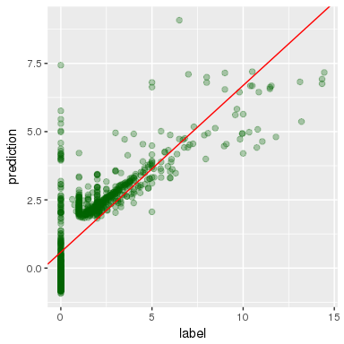

```r
# Sample predictions for plotting
predictedSampled <- predfilt_local[base::sample(1:nrow(predfilt_local), 1000),]

# Plot predicted vs. actual values
lm_model <- lm(prediction ~ label, data = predictedSampled)
ggplot(predictedSampled, aes(label, prediction)) +
  geom_point(col='darkgreen', alpha=0.3, pch=19, cex=2)   +
  geom_abline(aes(slope = summary(lm_model)$coefficients[2,1],
                  intercept = summary(lm_model)$coefficients[1,1]),
              color = "red")
```

```r
endtime <- Sys.time();
print (endtime - starttime);
```

```
## Time difference of 1.864072 secs
```

# 8 Save data & model

## 8.1 Save model for deployment

```r
###########################################
## SAVE MODEL [REMOVE FILE IF IT EXISTS]
###########################################
if (length(system("hadoop fs -ls /user/RevoShare/remoteuser/Models/SparkGlmModel", intern=TRUE))>=1) {
  system("hadoop fs -rm -r /user/RevoShare/remoteuser/Models/SparkGlmModel")
}
modelPath =  file.path("/user/RevoShare/remoteuser/Models", "SparkGlmModel");
write.ml(model, modelPath)
```

## 8.2 Save joined and sampled data

Repartition the data in specific number of chunks and save

```r
###########################################
# REPARTITION DATA FOR SAVING
###########################################
starttime <- Sys.time();

trip_fare_featRepartitioned <- repartition(trip_fare_feat, 10) # write.df below will produce this many files

###########################################
# SAVE DATAFRANE AS PARQUET file
###########################################
write.df(df=trip_fare_featRepartitioned,
         path=file.path(fullDataDir, "NYCjoinedParquetSubset"),
         source="parquet", mode="overwrite")

endtime <- Sys.time();
print (endtime - starttime);
```

```
## Time difference of 8.022501 secs
```

# 9 Uncache data and exit spark

```r
###########################################
# UNPERSIST CACHED DATA FRAME
###########################################
SparkR::unpersist(tripDF)
```

```
## SparkDataFrame[medallion:string, hack_license:string, vendor_id:string, rate_code:int, store_and_fwd_flag:string, pickup_datetime:timestamp, dropoff_datetime:timestamp, passenger_count:int, trip_time_in_secs:int, trip_distance:double, pickup_longitude:double, pickup_latitude:double, dropoff_longi…
```

```r
SparkR::unpersist(fareDF)
```

```
## SparkDataFrame[medallion:string, hack_license:string, vendor_id:string, pickup_datetime:timestamp, payment_type:string, fare_amount:double, surcharge:double, mta_tax:double, tip_amount:double, tolls_amount:double, total_amount:double]
```

```r
SparkR::unpersist(trip_fareDF)
```

```
## SparkDataFrame[pickup_datetime:timestamp, pickup_hour:int, dropoff_datetime:timestamp, dropoff_hour:int, vendor_id:string, fare_amount:double, surcharge:double, tolls_amount:double, tip_amount:double, payment_type:string, rate_code:int, passenger_count:int, trip_distance:double, trip_time_in_secs…
```

```r
SparkR::unpersist(trip_fare_feat)
```

```
## SparkDataFrame[payment_type:string, pickup_hour:int, fare_amount:double, tip_amount:double, passenger_count:int, trip_distance:double, trip_time_in_secs:int, TrafficTimeBins:string, tipped:int]
```

```r
SparkR::unpersist(trip_fare_featSampled)
```

```
## SparkDataFrame[payment_type:string, pickup_hour:int, fare_amount:double, tip_amount:double, passenger_count:int, trip_distance:double, trip_time_in_secs:int, TrafficTimeBins:string, tipped:int]
```

```r
###########################################
# LIST FILES FROM HDFS
###########################################
system("hadoop fs -ls /user/RevoShare/remoteuser/Data/NYCjoinedParquetSubset")
system("hadoop fs -ls /user/RevoShare/remoteuser/Models")

###########################################
# STOP SPARKR CONTEXT
###########################################
sparkR.stop()
```

# 10 Summary

The examples shown here can be adopted to fit other data exploration and modeling scenarios having different data-types or prediction tasks (e.g. classification).